# Large Scale Classification of Clinical Dermatology Images for Early Stage Melanoma Detection

[figure not shown]

## Abhishek Bhattacharya & Dexter Hadley

# Outline

- **Melanoma Primer**
  - Demographics
  - Progression
  - Management
- **Original diagnostic approach**
  - Follow ABCDE model
  - Hand picked feature selection
- **Why Deep Learning?**
  - Unreasonable Effectiveness of Deep Learning
  - Applying it to our problem
- **Results**
  - ROC Curve
  - tSNE
- **Ongoing work**
  - What's next for the project

# Melanoma Overview

- 73,000 new cases estimated this year -> 9,000 deaths are expected to occur
  - 5th most common type of cancer in America
- Highly surviveable with early detection
  - Stage IA 5-year survival rate is 97%
  - Stage IV 5-year survival rate is 20-10%
- Aggressive excisional biopsies is the mainstay of melanoma treatment

## 30 biopsies of melanocytic lesions have to be performed for every melanoma confirmed by pathology!

# Pathophysiology

- Melanoma typically arises in pigment (melanin) producing cells known as melanocytes

[figure not shown]

- High UV radiation produces (CPD) cyclobutane pyrimidine dimers in DNA
- Damaged DNA leads to uncontrolled cell growth
- Mutations in CDKN2A, CDK4, and MC1R genes can indicate high-risk for Melanoma

# Cancer Progression

[figure not shown]

# Melanoma Diagnosis lacks precision

- No biomarker available for diagnosis
- Subjective visual inspection
  - ABCDE Method
  - Ugly Duckling
- Current Gold Standard is Histopathology
  - Subjective interpretation
  - Low concordance among inter raters

# ABCDE

[figure not shown]

# Ugly Duckling

[figure not shown]

## Examples of Benign and Atypical

## Benign

### Melanocytic nevus

[figure not shown]

### Halo nevus

[figure not shown]

## Atypical

[figure not shown]

# Our Goals:

## Train machine learning algorithms to classify pigmented lesions from images

## Develop a mobile application to predict pathology from images

## Original Approach

- Hand picked feature selection based on ABCDE model
- Image segmentation using OpenCV and Sci-kit Image libraries

# Edge Detection

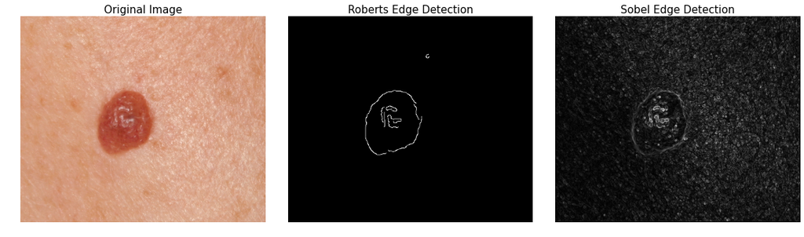

```python
show()
```

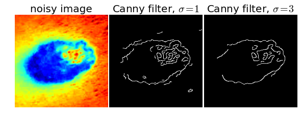

```python
show()
```

# Segmentation

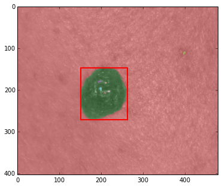

```python
show()
```

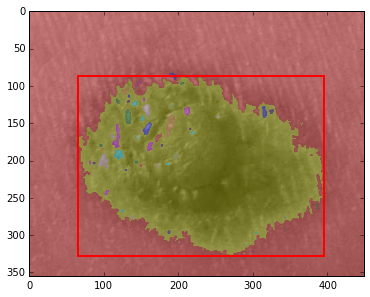

```python
show()
```

# Feature Selection

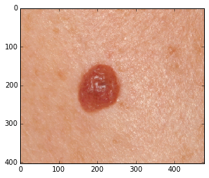

```python
show()
```

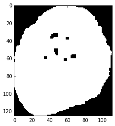

```
0.574270317164
```

```python
show()
```

## Problems with this approach

- Very time consuming
- Not robust and easily affected by noise
- Tough to adapt to more complex set of data

# Why is Deep Learning the Answer?

[figure not shown]

*[DeCAF] [Zeiler-Fergus]* *Classes separate in the deep representations and transfer to many tasks.*

**When Big Data meets Old School Machine Learning**

**Compositional Models**

**Learned End-to-End**

**Hierarchy of Representations**

- vision: pixel, motif, part, object
- text: character, word, clause, sentence
- speech: audio, band, phone, word

**Concrete** -->(learning) **Abstract**

Able to build hierachials model and generalize abstractions

# What is Deep Learning?

[figure not shown]

**Network of nodes loosely modeled after the human neuron**

Each node performs simple calculations (i.e. sigmoid, tanh funcs)

Each layer successively becomes abstracted from the raw data

**Non-Linear transformations**

**Backpropagation**

**Weights allow neurons to know when to fire**

- Iterative algorithm
- **More data --> better the performance (brute force understanding)**
- **Take in unlabeled data as well as labeled data**
  - Do unsupervised learning
  - Build a supervised learning model on top

# Neuron

[figure not shown]

```python
getIframe("http://caffe.berkeleyvision.org/gathered/examples/web_demo.html")
```

[interactive chart not shown]

# Convolutional Neural Networks for Image Classification

**LeNet** (Old)

[figure not shown]

# ImageNet

[figure not shown]

# Comparing CV to DL on ImageNet

[figure not shown]

# Applying CNNs to our problem

- Using Caffe developed out of Berkeley Vision Lab
  - Open code and reference models
- **Not enough data to do full end-to-end learning (need in the order of thousands)**
- Obtain data from DermNet (online data base with skin lesion images)
- **Use transfer learning to achieve quick but meaningful results**
  - Use CNN as a fixed feature extractor
    - Pre-trained model from ImageNet
    - AlexNet model from 2012 (modified slightly)
  - Take a 4096D vector output for each image
  - Run a SVM (Support Vector Machine) on the data
- **Use the SVM to do binary classification**

## Images from DermNet

- Scraped the site for pigmented lesions
- Created a binary training/validation set consisting of:
  - **Atypical**: Malignant Melanoma and atypical images included. **Total: 174**
  - **Melanocytic Nevus**: Halo Nevus, Blue Nevus, and melanocytic images included. **Total: 105**

    **Total Images: 279**

    *tagged by DermNet*

```python
getIframe("http://www.dermnet.com/")
```

[interactive chart not shown]

## Prediction

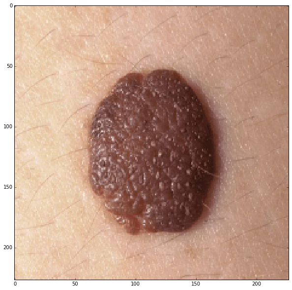

```python
net.blobs['data'].data[...] = transformer.preprocess('data', caffe.io.load_image(caffe_root + 'examples/images/mole8.JPG'))
out = net.forward() # PASSING THROUGH NEURAL NETWORK

plt.imshow(transformer.deprocess('data', net.blobs['data'].data[0]))
```

```python
print labels[top_k]
```

```
['n02319095 sea urchin'
 'n01496331 electric ray, crampfish, numbfish, torpedo'
 'n02172182 dung beetle' 'n03717622 manhole cover' 'n03530642 honeycomb']
```

## Visualization of Current Model

[figure not shown]

## List of Layers

```python
[(k, v[0].data.shape) for k, v in net.params.items()]
```

```
[('conv1', (96, 3, 11, 11)),
 ('conv2', (256, 48, 5, 5)),
 ('conv3', (384, 256, 3, 3)),
 ('conv4', (384, 192, 3, 3)),
 ('conv5', (256, 192, 3, 3)),
 ('fc6', (4096, 9216)),
 ('fc7', (4096, 4096)),
 ('fc8', (1000, 4096))]
```

## First Conv Layer

first set of 96 filters with 3(RGB) x 11 x 11 patches

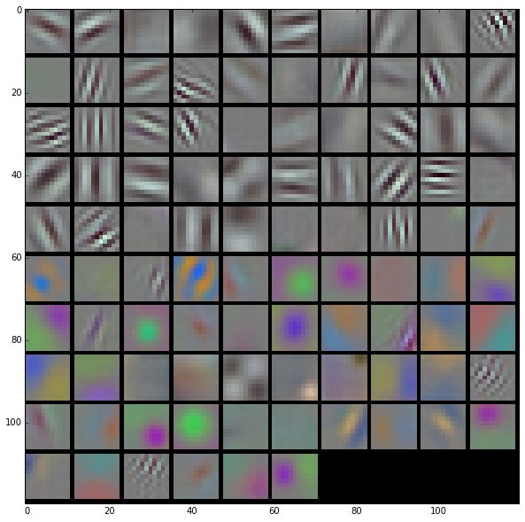

```python
# the parameters are a list of [weights, biases]
filters = net.params['conv1'][0].data
vis_square(filters.transpose(0, 2, 3, 1))
```

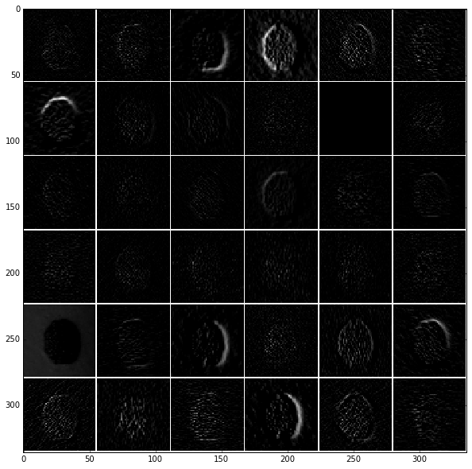

```python
## After Rectified Non-Linearity (type of function) pass

feat = net.blobs['conv1'].data[0, :36]
vis_square(feat, padval=1)
```

## Second Conv Layer

The second layer filters, `conv2`

There are 256 filters, each of which has dimension 5 x 5 x 48. We show only the first 48 filters, with each channel shown separately, so that each filter is a row.

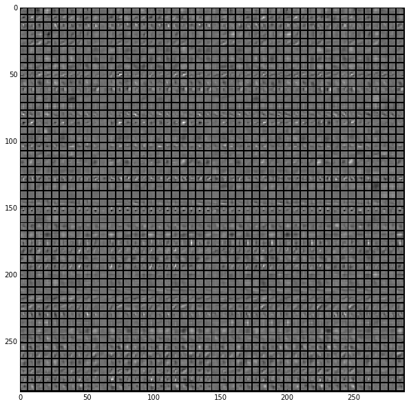

```python
filters = net.params['conv2'][0].data
vis_square(filters[:48].reshape(48**2, 5, 5))
```